### data exploration with SparkR 2.0.2

```
library(SparkR)

SparkR：連接使用Spark生態系統功能套件。安裝Spark後會存放在目錄，例如C:\spark-2.0.2-bin-hadoop2.7/R/lib
```

Spark 是以 JVM 為主的數據處理引擎，具分散特性，能夠組成強大的叢集運算系統。這優點恰好可以解決 R 在處理大量數據時的不足(R運算受限於本機的memory)，而 SparkR 不但是這兩者的橋接器，它也帶來了分散平行運算的能力，關於 [SParkR 的介紹](https://www.youtube.com/watch?v=5o-9ozwQgMw)可以參考這個影片，下圖是影片裡頭的畫面，也是理解使用 SparkR 的重要概念…

R 有 DataFrame 資料結構，SparkR 有 SparkDataFrame，雖然都有 DataFrame 字眼，但內涵意義有所不同，下圖我的理解是使用 SparkR createDataFrame() 方法會在 JVM 建立 SparkDataFrame 物件，而使用 SparkR collect() 方法則拉回本機產生 DataFrame 物件，表示在處理大數據時應多利用 SparkDataFrame 物件、盡量減少 I/O (轉換DataFrame) 次數，這樣使用 SparkR 才有意義。簡單的說，利用 Spark 進行資料處理，使用 R 來分析和視覺化，發揮各自的長處

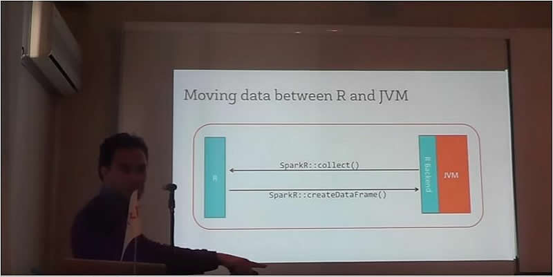

接下來將利用 SparkR 進行資料探索，內容是參考[http://ampcamp.berkeley.edu](http://ampcamp.berkeley.edu/5/exercises/sparkr.html)，使用的[資料集](http://d12yw77jruda6f.cloudfront.net/training-downloads.zip)也是，不過連結中使用的是 1.x 版，這裡使用的是 Spark 2.0.2，語法上多有差異。首先建立 SparkSession 物件，串起與 SparkR 的連線，原先 1.x 版的 SparkContext 與 SQLContext 物件已經被 SparkSession 取代了，由於 Spark 安裝於本機測試，這裡位置指定local，使用4個 threads 來執行(看機器有多少核心就設多少，也可用*代替)

```r
# ini a new SparkSession
sparkR.session(master = "local[4]", sparkConfig = list(spark.driver.memory = "2g"))
```

1. 讀入資料、建立SparkDataFrame物件(sdf)

```r
# Create a SparkDataFrame from a text file.
sdf <- read.text(file.path(Sys.getenv('SPARK_HOME'),'data','tsv_wiki'))
```

2. 查看sdf前3筆資料。原有連結使用 take 方法，會轉換成R的DataFrame (在處理大量資料可能會增加loading)

```r
showDF(sdf, 3)
```

```
## +--------------------+
## |               value|
## +--------------------+
## |14485903    List of ...|
## |19408264    Rio Colo...|
## |25879986    Jason Wa...|
## +--------------------+
## only showing top 3 rows
```

3. 查看筆數

```r
# Returns the number of items in a group
count(sdf)
```

```
## [1] 7967
```

4. 將半結構化的資料，拆解成具有schema (id, title, modified, text, username) 的 SparkDataFrame

```r
parseFields <- function(x) {
  Sys.setlocale("LC_ALL", "C") # necessary for strsplit() to work correctly
  parts <- strsplit(x, "\t")[[1]]
  ls <- list(id=parts[1], title=parts[2], modified=parts[3], text=parts[4], username=parts[5])
}

parsedRDD <- createDataFrame(lapply(collect(sdf)[,1], parseFields))

showDF(parsedRDD, 3)
```

```
## +--------+--------------------+----------+--------------------+-----------+
## |      id|               title|  modified|                text|   username|
## +--------+--------------------+----------+--------------------+-----------+
## |14485903|List of members o...|1390268521|{{List of members...|       null|
## |19408264|Rio Colorado Form...|1369547457|{{Infobox rockuni...|Ashorocetus|
## |25879986|  Jason Walter Brown|1397506167|{{Use mdy dates|d...|  Waacstats|
## +--------+--------------------+----------+--------------------+-----------+
## only showing top 3 rows
```

5. 查看筆數(筆數應與sdf相同)

```r
count(parsedRDD)
```

```
## [1] 7967
```

6. SparkR 有2種programming model類型，使用 SparkDataFrame APIs 和 SQL

先過濾掉username中有null的資料，check筆數

- using SparkDataFrame APIs

```r
printSchema(parsedRDD)
```

```
## root
##  |-- id: string (nullable = true)
##  |-- title: string (nullable = true)
##  |-- modified: string (nullable = true)
##  |-- text: string (nullable = true)
##  |-- username: string (nullable = true)
```

```r
# filter NA
nonEmptyUsernames <- filter(parsedRDD, isNotNull(parsedRDD$username))
# 同上
# nonEmptyUsernames <- filter(parsedRDD, 'username IS NOT null')
count(nonEmptyUsernames)
```

```
## [1] 6829
```

- using SQL

```r
# create and register as a temporary view
createOrReplaceTempView(parsedRDD, 'sdfView')
nonEmptyUsernames2 <- sql('SELECT username FROM sdfView WHERE username IS NOT null')
count(nonEmptyUsernames2)
```

```
## [1] 6829
```

出現次數最多的前10位users

- using SparkDataFrame APIs

```r
# groupBy
userCounts <- count(groupBy(nonEmptyUsernames, 'username'))
showDF(arrange(userCounts, desc(userCounts$count)), 10)
```

```
## +--------------+-----+
## |      username|count|
## +--------------+-----+
## |     Waacstats|  393|
## |      BattyBot|  191|
## |       Cydebot|  186|
## |         Yobot|  184|
## |        Addbot|  176|
## |       Monkbot|  126|
## |    ClueBot NG|   85|
## |ChrisGualtieri|   79|
## |   RjwilmsiBot|   77|
## |     AnomieBOT|   67|
## +--------------+-----+
## only showing top 10 rows
```

- using SQL

```r
userCounts2 <- sql('SELECT username,count(*) AS count FROM sdfView WHERE username IS NOT null GROUP BY username')
showDF(arrange(userCounts2, desc(userCounts2$count)), 10)
```

```
## +--------------+-----+
## |      username|count|
## +--------------+-----+
## |     Waacstats|  393|
## |      BattyBot|  191|
## |       Cydebot|  186|
## |         Yobot|  184|
## |        Addbot|  176|
## |       Monkbot|  126|
## |    ClueBot NG|   85|
## |ChrisGualtieri|   79|
## |   RjwilmsiBot|   77|
## |     AnomieBOT|   67|
## +--------------+-----+
## only showing top 10 rows
```

轉成R的DataFrame, using R’s plot

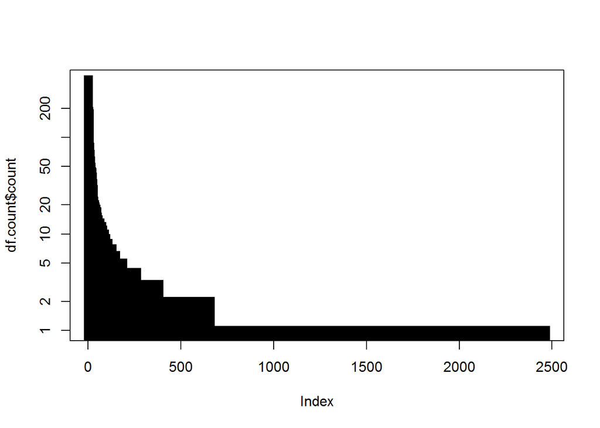

```r
# plot
df.count <- collect(arrange(userCounts, desc(userCounts$count)))
plot(df.count$count, log="y", type="h", lwd=10, lend=2)
```

7. 最後找出包含California字眼的文件筆數
- using SparkDataFrame APIs

```r
# count articles contain the word “California"
texts <-  filter(parsedRDD, "text like '%California%'")
count(texts)
```

```
## [1] 5795
```

- using SQL

```r
texts2 <- sql("SELECT * FROM sdfView WHERE text like '%California%'")
count(texts2)
```

```
## [1] 5795
```

8. 關閉session

```r
sparkR.session.stop()
```

比較SparkR 1.x 與 2.0 的語法發現，在解析非(半)結構化raw data時，還是得利用一些R base 語法來結合SparkR，不過一旦轉成有schema的 SparkDataFrame，接下來的處理就容易多了(SparkDataFrame APIs 和 SQL的應用)。2.0 版中很多語法也變的直覺簡單，尤其熟SQL的朋友可以直接用SQL語法，不一定非得用SparkDataFrame APIs，其他像是 merge 和 join 等也都有支援，相當方便。Spark 2.0 在 RDD 上層多了 SparkDataFrame，R使用者不必去面對難搞的RDD，只要對SparkDataFrame進行操控就好，亦即使用SparkR去做ETL工作，分析的任務再交給R.

### Lessons Learned:

#### Data Exploration with SparkR and SQL